# Analiza ekonometryczna czynników determinujących kurs Bitcoina w latach 2023–2026.

Michał Dyrga & Nikodem Kusiak

# Opis tematu.

Celem pracy jest *analiza ekonometryczna* kursu **Bitcoina** w latach 2023–2026. Jako zmienne objasiniające wybrano: **Złoto, S&P 500, USD Index**.

### 1. Zaczytanie bibliotek na których będziemy pracować.

```r
library(dplyr)
library(readr)
library(lubridate)   # change to "Date" type
library(skimr)       # present stats about our data frame
library(tseries)     # Testy stacjonarności (ADF, KPSS)
library(lmtest)      # Testy dla modeli (np. Breuscha-Pagana, Durbina-Watsona, RESET)
library(car)         # Testowanie współliniowości (VIF)
library(sandwich)    # Odporne błędy standardowe
library(strucchange) # Test Chowa
library(randtests)   # Test liczby serii
```

### 2. Zaczytanie danych na których będziemy pracować. Oraz odrazu je oczyścimy i przygotujemy do analizy:

- z racji, że **S&P 500** posiada dodatkową kolumnę, usuwamy ją ponieważ pozostałe zmienne jej nie zawierają,
- zmieniamy format kolumny **data** na *“Date”*, zamiast *“char”*,
- wybierzemy **kolumnę zamkniecia** która będzie *ceną reprezentatywną* w danym dniu.

```r
btc <- read.csv("data/btcusd_d.csv") %>% mutate(Data = ymd(Data)) %>% select(Data, btc = Zamkniecie)
spx <- read.csv("data/spx_d.csv") %>% mutate(Data = ymd(Data)) %>% select(Data, spx = Zamkniecie)
usd <- read.csv("data/usd_i_d.csv") %>% mutate(Data = ymd(Data)) %>% select(Data, usd = Zamkniecie)
xau <- read.csv("data/xauusd_d.csv") %>% mutate(Data = ymd(Data)) %>% select(Data, xau = Zamkniecie)
```

### 3. Stworzenie data frame.

Aby móc jak najlepiej przeanalizować dane, musimy stworzyć jeden **data frame** który będzie przechowywał dla danej daty informcję z ceną dla poszczególnych zmiennych.

```r
df <- btc %>%
  left_join(usd, by = "Data") %>%
  left_join(spx, by = "Data") %>%
  left_join(xau, by = "Data")
```

### 4. Usuwamy wiersze które nie posiadają danych.

```r
df <- na.omit(df) # deleting rows with missing data.
skim(df) # showing df stats
```

Data summary

| Name | df |
| --- | --- |
| Number of rows | 752 |
| Number of columns | 5 |
| _______________________ |  |
| Column type frequency: |  |
| Date | 1 |
| numeric | 4 |
| ________________________ |  |
| Group variables | None |

**Variable type: Date**

| skim_variable | n_missing | complete_rate | min | max | median | n_unique |
| --- | --- | --- | --- | --- | --- | --- |
| Data | 0 | 1 | 2023-04-03 | 2026-04-01 | 2024-09-30 | 752 |

**Variable type: numeric**

| skim_variable | n_missing | complete_rate | mean | sd | p0 | p25 | p50 | p75 | p100 | hist |
| --- | --- | --- | --- | --- | --- | --- | --- | --- | --- | --- |
| btc | 0 | 1 | 69942.65 | 29420.00 | 25119.00 | 42742.72 | 67878.70 | 95398.60 | 125173.00 | ▇▅▆▆▅ |
| usd | 0 | 1 | 63.24 | 1.62 | 59.95 | 61.85 | 63.22 | 64.53 | 67.20 | ▅▇▇▇▂ |
| spx | 0 | 1 | 5542.02 | 869.34 | 4055.99 | 4756.03 | 5598.21 | 6226.00 | 6978.60 | ▇▅▇▇▇ |
| xau | 0 | 1 | 2840.62 | 910.19 | 1820.26 | 2028.61 | 2606.90 | 3344.81 | 5415.17 | ▇▃▂▂▁ |

> **Wnioksi:**
> - Posiadamy 752 wiersze, czyli 750 stopni swobody, co zapewnia wiarygodne wyniki testów,
> - zakres czasowy od kweitnia 2023, do kwietnia 2026,
> - 4 kolumny numeryczne, 1 typu *Date*.

# Analiza posiadanych danych

### 1. Zapoznajmy się z oczyszczonymi danymi.

```r
summary(df)
```

```
##       Data                 btc              usd             spx
##  Min.   :2023-04-03   Min.   : 25119   Min.   :59.95   Min.   :4056
##  1st Qu.:2024-01-01   1st Qu.: 42743   1st Qu.:61.85   1st Qu.:4756
##  Median :2024-09-30   Median : 67879   Median :63.22   Median :5598
##  Mean   :2024-09-30   Mean   : 69943   Mean   :63.24   Mean   :5542
##  3rd Qu.:2025-07-02   3rd Qu.: 95399   3rd Qu.:64.53   3rd Qu.:6226
##  Max.   :2026-04-01   Max.   :125173   Max.   :67.20   Max.   :6979
##       xau
##  Min.   :1820
##  1st Qu.:2029
##  Median :2607
##  Mean   :2841
##  3rd Qu.:3345
##  Max.   :5415
```

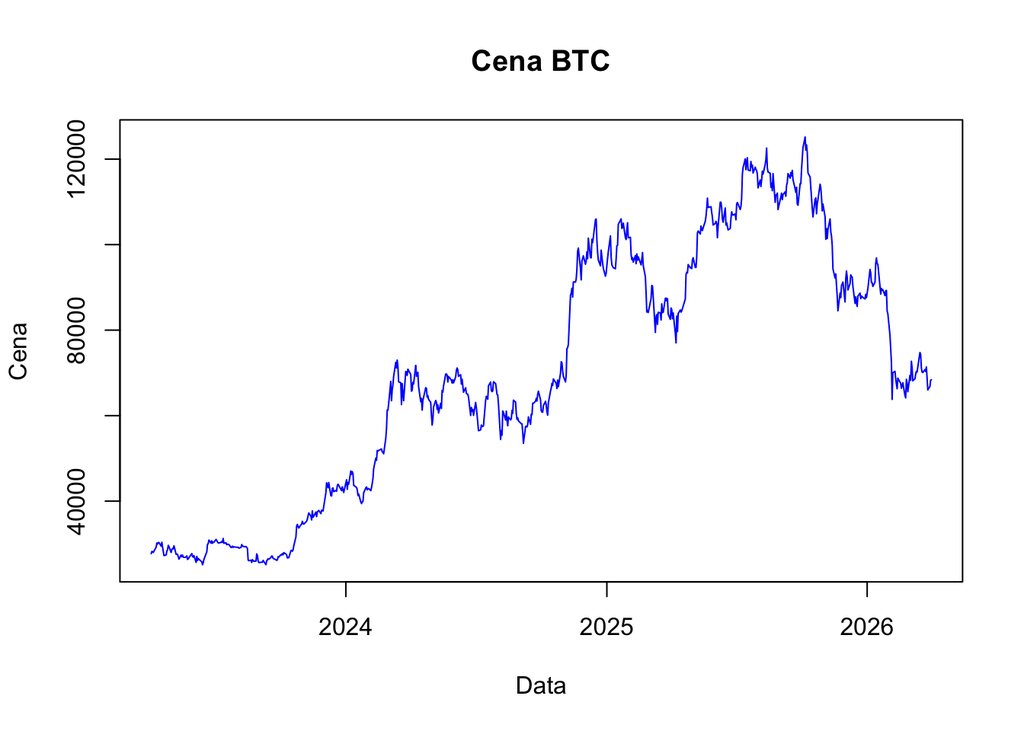

```r
plot(df$Data, df$btc, type="l", col="blue", main="Cena BTC", xlab="Data", ylab="Cena")
```

> **Wnioski:**
> - cena Bitcoina wskazje w 2024 roku *tendencję wzrostową*, szczególnie w I kwartale oraz IV kwartale 2024 roku,
> - w roku 2026 na rynku Bitcoina doszło do *głębokiej korekty spadkowej*, w wyniku której cena aktywa uległa spadku o około 50% w stosunku do szczytu wartości

### 2. Analiza korelacji danych.

```r
cor_matrix <- cor(df[, c("btc", "usd", "spx", "xau")])
cor_matrix
```

```
##            btc        usd        spx        xau
## btc  1.0000000 -0.2809151  0.8508109  0.6603372
## usd -0.2809151  1.0000000 -0.4073593 -0.5718519
## spx  0.8508109 -0.4073593  1.0000000  0.8958694
## xau  0.6603372 -0.5718519  0.8958694  1.0000000
```

> **Wnioski:**
> - **BTC vs USD (-0.28)**: korelacja jest ujemna, korelacja jest słaba co oznaczam, że ta zmienna nie opisuje najlepiej ceny BTC,
> - **BTC vs SPX (0.85)**: bardzo silna korelacja dodatnia, BTC zachowuje się obecnie jak aktywo wysokiego ryzyka, korelując się z indeksem 500 największych spółek w USA,
> - **BTC vs XAU (0.66)**: korelacja jest umiarkowanie silna, BTC można nazywać jako cyforwe złoto, ale wciąż mocniej koreluje z giełdą SPX,
> - **SPX vs XAU (0.89)**: korelacja między dwiema zmiennymi objaśniającymi jest bardzo wysoka, podejrzenie **współliniowowści**, które zbadamy w późniejszej analizie.

### 3. Badanie stacjonarności szeregów czasowych

Zgodnie z teorią MNK, badamy **stacjonarność**, aby uniknąć problemu regresji pozornej. Wykorzystujemy Test ADF (Augmented Dickey-Fuller test).

- **H0**: szereg czasowy nie jest stacjonarny
- **H1**: szereg czasowy jest stacjonarny

```r
adf.test(df$btc)
```

```
##
##  Augmented Dickey-Fuller Test
##
## data:  df$btc
## Dickey-Fuller = -0.81161, Lag order = 9, p-value = 0.9606
## alternative hypothesis: stationary
```

```r
adf.test(df$usd)
```

```
##
##  Augmented Dickey-Fuller Test
##
## data:  df$usd
## Dickey-Fuller = -2.3821, Lag order = 9, p-value = 0.4166
## alternative hypothesis: stationary
```

```r
adf.test(df$spx)
```

```
##
##  Augmented Dickey-Fuller Test
##
## data:  df$spx
## Dickey-Fuller = -2.2986, Lag order = 9, p-value = 0.4519
## alternative hypothesis: stationary
```

```r
adf.test(df$xau)
```

```
##
##  Augmented Dickey-Fuller Test
##
## data:  df$xau
## Dickey-Fuller = -1.866, Lag order = 9, p-value = 0.635
## alternative hypothesis: stationary
```

> **Wnioski:**
> - p-value testu ADF dla wszystkich zmiennych wynosi ponad 0.05, w związku z czym brak podstaw aby odrzucić H0, zmienne są niestacjonarne. Budowanie modelu na takich danych prowadziłoby do błędnych wniosków.

### 4. Potweirdzenie testu ADF.

Dla potwierdzenia skorzystajmy z testu KPSS (Kwiatkowskiego-Phillipsa-Schmidta-Shina) którego hipotezy są odwrócone.

- **H0**: szereg czasowy jest stacjonarny
- **H1**: szereg czasowy nie jest stacjonarny

```r
kpss.test(df$btc)
```

```
##
##  KPSS Test for Level Stationarity
##
## data:  df$btc
## KPSS Level = 8.6967, Truncation lag parameter = 6, p-value = 0.01
```

```r
kpss.test(df$usd)
```

```
##
##  KPSS Test for Level Stationarity
##
## data:  df$usd
## KPSS Level = 3.2048, Truncation lag parameter = 6, p-value = 0.01
```

```r
kpss.test(df$spx)
```

```
##
##  KPSS Test for Level Stationarity
##
## data:  df$spx
## KPSS Level = 10.168, Truncation lag parameter = 6, p-value = 0.01
```

```r
kpss.test(df$xau)
```

```
##
##  KPSS Test for Level Stationarity
##
## data:  df$xau
## KPSS Level = 9.5487, Truncation lag parameter = 6, p-value = 0.01
```

> **Wnioski:**
> - potwierdzenie, że ceny są niestacjonarne, p-value < 0,05, odrzucamy H0, w związku z czym musimy zmodyfikować nasze dane aby szereg był stacjonarny.

### 5. Modyfikacja danych.

Lepszym rozwiązaniem będzie **analiza stóp zwrotu**, które badają codzienne zmiany cen. Stopy zwrotu są stacjonarne, dzięki czemu możemy zbadać, jak mocno te rynki na siebie wpływają.

```r
df_returns <- df %>%
  arrange(Data) %>%
  mutate(
    r_btc = c(NA, diff(log(btc))),
    r_usd = c(NA, diff(log(usd))),
    r_spx = c(NA, diff(log(spx))),
    r_xau = c(NA, diff(log(xau)))
  ) %>%
  na.omit() # remove row, which is NA after diff() - differences beetwen values

adf.test(df_returns$r_btc)
```

```
##
##  Augmented Dickey-Fuller Test
##
## data:  df_returns$r_btc
## Dickey-Fuller = -8.0891, Lag order = 9, p-value = 0.01
## alternative hypothesis: stationary
```

```r
adf.test(df_returns$r_usd)
```

```
##
##  Augmented Dickey-Fuller Test
##
## data:  df_returns$r_usd
## Dickey-Fuller = -8.7503, Lag order = 9, p-value = 0.01
## alternative hypothesis: stationary
```

```r
adf.test(df_returns$r_spx)
```

```
##
##  Augmented Dickey-Fuller Test
##
## data:  df_returns$r_spx
## Dickey-Fuller = -8.7239, Lag order = 9, p-value = 0.01
## alternative hypothesis: stationary
```

```r
adf.test(df_returns$r_xau)
```

```
##
##  Augmented Dickey-Fuller Test
##
## data:  df_returns$r_xau
## Dickey-Fuller = -9.4052, Lag order = 9, p-value = 0.01
## alternative hypothesis: stationary
```

> **Wnioski:**
> - dla wszystkich analizowanych zmiennych w postaci stóp zwrotu, test ADF pozwolił na odrzucenie hipotezy zerowej o niestacjonarności przy poziomie istotności p < 0,01. Szeregi są stacjonarne i umożliwiają dalszą estymację modelu.”

### 6. Dzielimy dane na zbiór uczący (80%) i testowy (20%).

```r
n_obs <- nrow(df_returns)
breakdown <- round(n_obs * 0.8)

df_learn <- df_returns[1:breakdown, ]
df_test <- df_returns[(breakdown + 1):n_obs, ]
```

### 7. Ponowna weryfikacja korelacji zmiennych na zbiorze uczącym.

```r
cor_learn <- cor(df_learn[, c("r_btc", "r_usd", "r_spx", "r_xau")])
cor_learn
```

```
##             r_btc       r_usd       r_spx       r_xau
## r_btc  1.00000000 -0.01770160  0.31868593  0.05135402
## r_usd -0.01770160  1.00000000 -0.02527268 -0.50034823
## r_spx  0.31868593 -0.02527268  1.00000000  0.06984523
## r_xau  0.05135402 -0.50034823  0.06984523  1.00000000
```

> **Wnioski:**
> - na podstawie obliczonych korelacji możemy zauważyć, że największa korelacja Bitcoina występuje z S&P 500, ponaddto korelacja zmiennej objaśniającej z pozostałymi propozycjami nie posiada zbyt dużej korleacji.

# Budowa modelu

Zastosowano metodę krokową wsteczną do wybrania ostatecznej postaci modelu.

```r
model_full <- lm(r_btc ~ r_usd + r_spx + r_xau, data = df_learn)
model_step <- step(model_full, direction = "backward")
```

```
## Start:  AIC=-4298.83
## r_btc ~ r_usd + r_spx + r_xau
##
##         Df Sum of Sq     RSS     AIC
## - r_usd  1  0.000017 0.46418 -4300.8
## - r_xau  1  0.000409 0.46457 -4300.3
## <none>               0.46416 -4298.8
## - r_spx  1  0.051570 0.51573 -4237.5
##
## Step:  AIC=-4300.81
## r_btc ~ r_spx + r_xau
##
##         Df Sum of Sq     RSS     AIC
## - r_xau  1  0.000440 0.46462 -4302.2
## <none>               0.46418 -4300.8
## - r_spx  1  0.051597 0.51578 -4239.5
##
## Step:  AIC=-4302.24
## r_btc ~ r_spx
##
##         Df Sum of Sq     RSS     AIC
## <none>               0.46462 -4302.2
## - r_spx  1  0.052521 0.51714 -4239.9
```

```r
summary(model_step)
```

```
##
## Call:
## lm(formula = r_btc ~ r_spx, data = df_learn)
##
## Residuals:
##       Min        1Q    Median        3Q       Max
## -0.112523 -0.016076 -0.001816  0.014270  0.136826
##
## Coefficients:
##             Estimate Std. Error t value Pr(>|t|)
## (Intercept) 0.001593   0.001139   1.398    0.163
## r_spx       0.969095   0.117770   8.229 1.18e-15 ***
## ---
## Signif. codes:  0 '***' 0.001 '**' 0.01 '*' 0.05 '.' 0.1 ' ' 1
##
## Residual standard error: 0.02785 on 599 degrees of freedom
## Multiple R-squared:  0.1016, Adjusted R-squared:  0.1001
## F-statistic: 67.71 on 1 and 599 DF,  p-value: 1.184e-15
```

> Algorytm krokowy zredukował model wyłącznie do jednej zmiennej objaśniającej – r_spx. Zmienne r_usd i r_xau zostały odrzucone, bo na stopach zwrotu praktycznie nie korelują z r_btc (odpowiednio -0.018 i 0.051). Co ciekawe, na stopach zwrotu znika też silna korelacja SPX i XAU widoczna na surowych wartosciach (z 0.90 do 0.07) — była ona pozorna i wynikała ze wspólnego trendu w długim okresie. Parametr przy zmiennej r_spx okazał się wysoce istotny statystycznie (p-value 1.18e-15).

## Weryfikacja poprawności modelu ekonometrycznego

Mając już oszacowany model trzeba sprawdzić czy są spełnione wszystkie założenia MNK.

### 1. Normalność rozkładu składnika losowego – test Jarque-Bera

- **H0**: składnik losowy ma rozkład normalny
- **H1**: nie ma rozkładu normalnego

```r
jarque.bera.test(residuals(model_step))
```

```
##
##  Jarque Bera Test
##
## data:  residuals(model_step)
## X-squared = 105.03, df = 2, p-value < 2.2e-16
```

> **Wnioski:** P-value bardzo małe < 2.2e-16, czyli odrzucamy H0. Reszty nie mają rozkładu normalnego. Nie jest to duży problem, bo próba jest duża i estymator MNK pozostaje zgodny.

### 2. Autokorelacja składnika losowego

Stosujemy dwa testy: Durbina-Watsona (autokorelacja I rzędu) oraz Breuscha-Godfreya (wyższe rzędy). * **H0**: brak autokorelacji * **H1**: występuje autokorelacja

```r
dwtest(model_step)
```

```
##
##  Durbin-Watson test
##
## data:  model_step
## DW = 2.0733, p-value = 0.8164
## alternative hypothesis: true autocorrelation is greater than 0
```

```r
bgtest(model_step)
```

```
##
##  Breusch-Godfrey test for serial correlation of order up to 1
##
## data:  model_step
## LM test = 0.83576, df = 1, p-value = 0.3606
```

> **Wnioski:** P-value 0.8164 i 0.3606, nie ma podstaw do odrzucenia H0. Autokorelacji w resztach nie ma, więc jedno z głównych założeń MNK jest spełnione - macierz wariancji-kowariancji składników losowych jest diagonalna.

### 3. Homoskedastyczność składnika losowego

Test Breuscha-Pagana oraz Goldfelda-Quandta. * **H0**: wariancja składnika losowego jest stała (homoskedastyczność) * **H1**: heteroskedastyczność

```r
bptest(model_step)
```

```
##
##  studentized Breusch-Pagan test
##
## data:  model_step
## BP = 5.7757, df = 1, p-value = 0.01625
```

```r
gqtest(model_step)
```

```
##
##  Goldfeld-Quandt test
##
## data:  model_step
## GQ = 0.876, df1 = 299, df2 = 298, p-value = 0.8734
## alternative hypothesis: variance increases from segment 1 to 2
```

> **Wnioski:** Wyniki testów są sprzeczne - BP zwrócił p-value 0.01625 (odrzucamy H0), a GQ p-value 0.8734 (H0 zostaje). BP wychwytuje ogólniejszą zależność wariancji od zmiennej objaśniającej, GQ tylko monotoniczną. Dla bezpieczeństwa zastosujemy później odporne błędy standardowe HAC.

### 4. Współliniowość

Współczynnik VIF.

```r
if (length(coef(model_step)) > 2) {
  vif(model_step)
} else {
  message("W modelu została tylko 1 zmienna objaśniająca, więc VIF nie ma sensu.")
}
```

```
## W modelu została tylko 1 zmienna objaśniająca, więc VIF nie ma sensu.
```

> **Wnioski:** Po eliminacji krokowej w modelu została jedna zmienna, więc nie ma jak obliczyć współczynnika VIF (potrzeba minimum dwóch zmiennych objaśniających).

### 5. Stabilność parametrów – test Chowa

- **H0**: parametry modelu są stabilne w czasie
- **H1**: parametry nie są stabilne

```r
sctest(formula(model_step), type = "Chow", point = floor(nrow(df_learn)/2), data = df_learn)
```

```
##
##  Chow test
##
## data:  formula(model_step)
## F = 0.95961, p-value = 0.3836
```

> **Wnioski:** P-value 0.3836, znowu H0 nie odrzucamy. Parametry są stabilne między pierwszą a drugą połową próby uczącej.

### 6. Postać analityczna i liniowość – test RESET (Ramseya) i test liczby serii

- **H0**: postać modelu jest dobrze dobrana, model jest liniowy
- **H1**: model nie jest liniowy

```r
resettest(model_step)
```

```
##
##  RESET test
##
## data:  model_step
## RESET = 2.6089, df1 = 2, df2 = 597, p-value = 0.07445
```

```r
runs.test(residuals(model_step))
```

```
##
##  Runs Test
##
## data:  residuals(model_step)
## statistic = 0.98061, runs = 313, n1 = 300, n2 = 300, n = 600, p-value =
## 0.3268
## alternative hypothesis: nonrandomness
```

> **Wnioski:** RESET podał wynik p-value 0.07445, test liczby serii 0.3268 - w obu nie odrzucamy H0 (przy α = 0.05), liniowa postać modelu jest poprawna.

### 7. Koincydencja

Patrzymy czy znak korelacji BTC ze SPX z macierzy zgadza się ze znakiem oszacowanego parametru w modelu.

```r
cor(df_learn$r_btc, df_learn$r_spx)
```

```
## [1] 0.3186859
```

```r
coef(model_step)
```

```
## (Intercept)       r_spx
## 0.001592552 0.969094687
```

> **Wnioski:** Korelacja BTC i SPX dodatnia (0.319), parametr przy r_spx też dodatni (0.969). Znaki się zgadzają, koincydencja spełniona.

## Uwiarygodnienie testów (HAC)

Wyniki testów heteroskedastyczności są sprzeczne, dla pewności sprawdziliśmy istotność zmiennej również przy użyciu odpornych błędów standardowych HAC.

```r
coeftest(model_step, vcov = vcovHAC(model_step))
```

```
##
## t test of coefficients:
##
##              Estimate Std. Error t value  Pr(>|t|)
## (Intercept) 0.0015926  0.0011477  1.3876    0.1658
## r_spx       0.9690947  0.1561791  6.2050 1.021e-09 ***
## ---
## Signif. codes:  0 '***' 0.001 '**' 0.01 '*' 0.05 '.' 0.1 ' ' 1
```

```r
waldtest(model_step, vcov = vcovHAC(model_step))
```

```
## Wald test
##
## Model 1: r_btc ~ r_spx
## Model 2: r_btc ~ 1
##   Res.Df Df      F    Pr(>F)
## 1    599
## 2    600 -1 38.502 1.021e-09 ***
## ---
## Signif. codes:  0 '***' 0.001 '**' 0.01 '*' 0.05 '.' 0.1 ' ' 1
```

P-value rzędu 10^-9 - parametr przy r_spx jest istotny nawet przy odpornych błędach. Wnioski się potwierdzają.

## Ostateczna postać modelu i jego ocena

Współczynnik determinacji $R^2$:

```r
summary(model_step)$r.squared
```

```
## [1] 0.1015607
```

Model jest oszacowany na stopach zwrotu (logarytmiczne pierwsze różnice), więc jest to prosta regresja liniowa:
$$r\_btc_i = \beta_0 + \beta_1 \cdot r\_spx_i +
\varepsilon_i$$

**Interpretacja parametru przy r_spx (ok. 0.97):** Jeśli stopa zwrotu SPX wzrośnie o 1 jednostkę (tj. o 1 p.p.), to stopa zwrotu BTC wzrośnie średnio o 0.97 jednostki, ceteris paribus. W praktyce: jak amerykańska giełda rośnie o 1%, to BTC rośnie średnio o ok. 0.97%.

R^2 = 0.1016, czyli model wyjaśnia ok. 10.2% zmienności stóp zwrotu BTC. Na pierwszy rzut oka to mało, ale na dziennych danych z rynku to całkiem dobrze - ruchy cen są w dużej części losowe i nawet zaawansowane modele rzadko schodzą wysoko.

## Prognoza na zbiorze testowym

```r
predykcje <- predict(model_step, newdata = df_test)

# RMSE – pierwiastek błędu średniokwadratowego
rmse <- sqrt(mean((df_test$r_btc - predykcje)^2))
cat("RMSE:", rmse, "\n")
```

```
## RMSE: 0.02640299
```

```r
# MAE – średni absolutny błąd
mae <- mean(abs(df_test$r_btc - predykcje))
cat("MAE:", mae, "\n")
```

```
## MAE: 0.02007188
```

```r
# MAPE – średni absolutny błąd procentowy
mape <- mean(abs((df_test$r_btc - predykcje) / df_test$r_btc), na.rm = TRUE) * 100
cat("MAPE:", round(mape, 2), "%\n")
```

```
## MAPE: 123.9 %
```

Na zbiorze testowym RMSE wyszło ok. 0.026, czyli średnio mylimy się o ok. 2.6 p.p. stopy zwrotu. MAPE wyszło 123.9%, ale tę miarę trzeba brać z dystansem - stopy zwrotu często krążą wokół zera, a kiedy dzielimy przez liczby bliskie zera to MAPE drastycznie wzrasta. Dlatego sensowniejsze są tu RMSE i MAE.

Podsumowując, nawet tak prosty model regresji liniowej z jedną zmienną pokazał istotny, dodatni związek między indeksem SPX a kursem BTC. W badanym okresie Bitcoin zachowywał się raczej jak aktywo wysokiego ryzyka skorelowane z giełdą amerykańską niż jak “cyfrowe złoto”.